# Week 4: More Likelihood Models

PS 818 - Data Analysis with Statistical Models

Anton Strezhnev

strezhnev@wisc.edu

University of Wisconsin-Madison

September 28, 2026

## More Likelihood Models

## Previously

- **Generalized linear models**

  $$g(\mathbb{E}[Y_i|X_i]) = X_i^{\prime}\beta$$
- **Binary outcome models**
  - Careful with interpreting the raw model coefficients
  - For a logit, $\beta_k$ is a change in **log-odds**, and $\frac{\partial \pi_i}{\partial X_{ik}} = \beta_k\pi_i(1-\pi_i)$
- **Inference on transformations**:
  - Invariance + **delta method**

## This week

- **Latent variables and discrete choice**
  - The latent-variable representation of the logit and probit
  - **Ordinal** logit and the proportional odds assumption
  - **Multinomial** logit and independence of irrelevant alternatives (IIA)
- **Random utility and conditional logit**
  - Choice data and alternative-specific covariates
  - The **model based** approach to **conjoint experiments**
- **Duration models**
  - Survival functions, the hazard, and censoring
  - Parametric, semi-parametric (Cox), and non-parametric (Kaplan-Meier) approaches

## “Latent variables” and logit

## Latent variables

- Another common way of formulating discrete outcome regressions is in terms of an unobserved continuous “latent” variable and an observation mechanism.
  - Instead of putting a distribution on $Y_i$, we put one on an unobserved $Y_i^*$
  - $Y_i$ is some function of $Y_i^*$ (usually an indicator function of some sort)
- For the logistic regression

  $$Y_i = \mathbb{1}(Y_i^* \ge 0)$$
  $$Y_i^* = X_i^{\prime}\beta + \epsilon_i$$
  $$\epsilon_i \sim \text{Logistic}(0, 1)$$
- The Logistic distribution is parameterized in terms of a “location” (mean) $\mu$ and a “scale” parameter $s>0$.
  - For $\mu = 0$, $s= 1$ we have the “standard” logistic

  $$\Pr(\epsilon_i \le x) = \frac{1}{1 + \exp(-x)}$$

## Latent variables

- So what’s $\mathbb{E}[Y_i|X_i] = \Pr(Y_i = 1|X_i)$?

  $$\Pr(Y_i = 1|X_i) = \Pr(Y_i^* \ge 0 | X_i) = \Pr(\epsilon_i \ge -X_i^{\prime}\beta) = \Pr(\epsilon_i \le X_i^{\prime}\beta) = \frac{1}{1 + \exp(-X_i^{\prime}\beta)}$$
  - The last-but-one step uses the **symmetry** of the logistic distribution around zero.
- We can write the **probit** similarly, defining the error distribution as

  $$\epsilon_i \sim \text{Normal}(0, 1)$$
- And by extension, the probability $\Pr(Y_i = 1|X_i)$

  $$\Pr(Y_i = 1|X_i) = \Pr(Y_i^* \ge 0|X_i) = \Pr(\epsilon_i \le X_i^{\prime}\beta) = \Phi(X_i^{\prime}\beta)$$
- **Note** the scale of $\epsilon_i$ is fixed by assumption, not estimated
  - $Y_i^*$ is never observed, so only the *ratio* $\beta/s$ is identified – so we normalize to $s =1$

## Latent variables

- We can visualize this as an integral over the density of the random “error” $\epsilon_i$

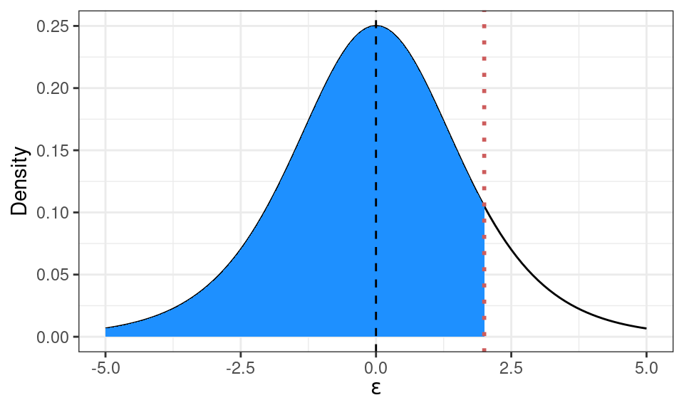

## Latent variables

- Same thing for a probit

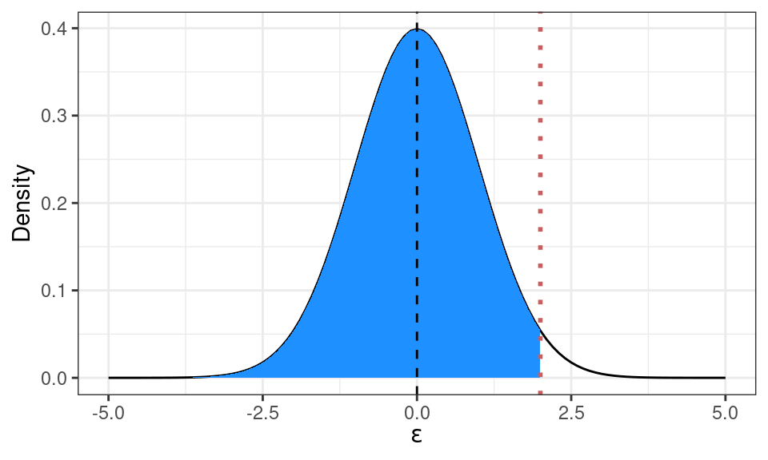

## Ordinal logit

- Using the latent variable formulation lets us extend binary outcome models to outcomes with multiple discrete levels.
- For example, consider an “ordinal” response variable
  - (e.g.) a Likert scale (1 = “strongly disagree”, 3 = “neutral”, 5 = “strongly agree”)
- The responses are *ordered* but the intervals between them do not have any meaning.
  - A popular modeling technique with an ordinal $Y$ is to treat it as an expression of a latent variable.

## Ordinal logit

- In an *ordered logit* model, an ordinal outcome $Y$ with $L$ unique, ordered values $Y \in \{1, 2, 3, \dotsc L\}$ is a function of a latent variable and a set of $L-1$ cutpoints $\kappa$

  $$Y_i = \begin{cases}1 &\text{if } Y_i^* \le \kappa_1 \\
  2 &\text{if } \kappa_1 < Y_i^* \le \kappa_2\\
  3 &\text{if } \kappa_2 < Y_i^* \le \kappa_3\\
  \vdots &\\
  L &\text{if } Y_i^* > \kappa_{L-1}\end{cases}$$
- We still assume $Y_i^*$ has a logistic distribution

  $$Y_i^* = X_i^{\prime}\beta + \epsilon_i, \qquad \epsilon_i \sim \text{Logistic}(0, 1)$$

## Ordinal logit

- To estimate the model, we now have to estimate both the $\beta$ parameters and the $\kappa$ parameters
  - Note we omit the intercept from $X_i$ – the $\kappa$ parameters are essentially the “intercepts” for each boundary between the choices.
- How does the model map changes in the latent variable to changes in probability? Work with the **cumulative** probabilities:

  $$\Pr(Y_i \le l \,|\, X_i) = \Pr(Y_i^* \le \kappa_l \,|\, X_i) = \Pr(\epsilon_i \le \kappa_l - X_i^{\prime}\beta)$$
- And then difference adjacent cumulatives to get each cell probability

  $$\Pr(Y_i = l \,|\, X_i) = \Pr(Y_i \le l \,|\, X_i) - \Pr(Y_i \le l-1 \,|\, X_i)$$

  with the conventions $\Pr(Y_i \le 0) = 0$ and $\Pr(Y_i \le L) = 1$.

## Ordinal logit

- Let’s think in terms of the distribution of $Y_i^*$ and the cut-points for a case with $L=3$. For $X_i^{\prime}\beta = 0$:

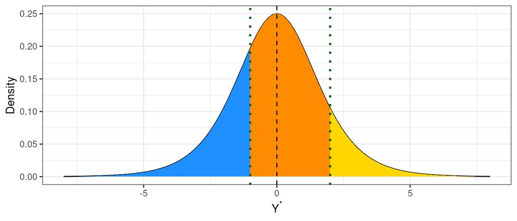

- The green lines are the cutpoints $\kappa_1, \kappa_2$; the shaded areas are $\Pr(Y_i = 1), \Pr(Y_i = 2), \Pr(Y_i = 3)$.

## Ordinal logit

- Shifting the mean of $Y^*$ up by 3:

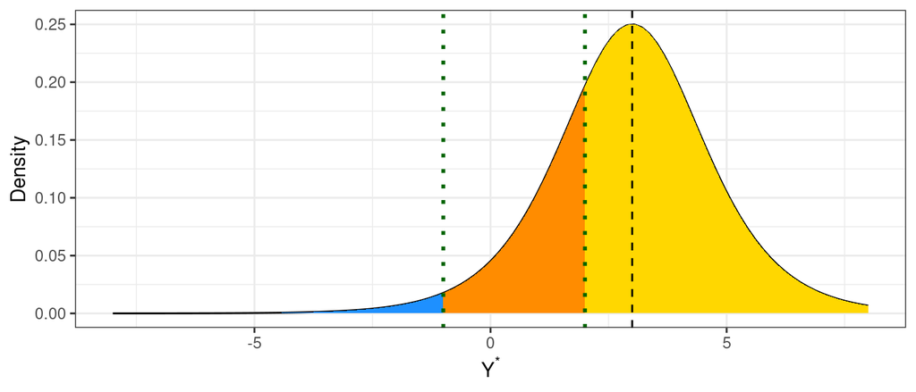

- The cutpoints stay put but the *distribution* slides. All three probabilities move together as a result.

## Ordinal logit

- This structural mapping from $Y^*$ to $\Pr(Y_i = l)$ encodes a particular assumption about how these probabilities relate to one another.
- Referred to as the **proportional odds** assumption

  $$\log\left(\frac{\Pr(Y_i \le l)}{1 - \Pr(Y_i \le l)}\right) = \kappa_l - X_i^{\prime}\beta$$
  - The same $\beta$ appears for *every* $l$; only the intercept $\kappa_l$ changes.
- **Intuitively**: the $\beta$ parameters are shared across all the possible outcome levels.
  - Information about whether someone responds “strongly agree” *also* tells us something about how likely they would be to respond “agree”, “neutral”, “disagree”, or “strongly disagree”.
  - Not innocuous if there’s non-monotonicity or heterogeneous effects.
  - Be careful with these models!

## Multinomial logit

- In a setting with multiple **unordered** outcomes, the natural extension of the logit regression is the **multinomial** logit
- Suppose we have an outcome with $K$ unordered levels (e.g. “choices”). Define a latent “utility” $Y_{ik}^*$ for each of the $K$ categories
  - For identification, we set one category to be the “baseline” by anchoring its coefficients to zero: $\beta_1 = 0$

  $$\begin{align*}Y_{i1}^* &= X_i^{\prime}\beta_1 + \epsilon_{i1} = \epsilon_{i1}\\
  Y_{i2}^* &= X_i^{\prime}\beta_2 + \epsilon_{i2}\\
  &\vdots \\
  Y_{iK}^* &= X_i^{\prime}\beta_K + \epsilon_{iK}\end{align*}$$
- The probability of observing choice $Y_{i} = k$ is the probability that the $k$th latent variable is greater than all of the others

  $$\Pr(Y_i = k \,|\, X_i) = \Pr\big(Y^*_{ik} = \max\{Y^*_{i1}, Y^*_{i2}, \dotsc Y^*_{iK}\}\big)$$

## Multinomial logit

- It turns out that if the error terms $\epsilon_{ik}$ have i.i.d. “Type I extreme value” distributions, we can write the choice probabilities in closed form

  $$\Pr(Y_i = k \,|\, X_i) = \frac{\exp(X_i^{\prime}\beta_{k})}{\sum_{k^\prime=1}^K \exp(X_i^{\prime}\beta_{k^\prime})}$$
- This is sometimes referred to as the “softmax” function in machine learning.
- **Note**: with the normalized baseline category $\beta_1 = 0$, we can write this equivalently as

  $$\Pr(Y_i = k \,|\, X_i) = \frac{\exp(X_i^{\prime}\beta_{k})}{1 + \sum_{k^\prime=2}^K \exp(X_i^{\prime}\beta_{k^\prime})}$$
- The i.i.d. error assumption implies **independence of irrelevant alternatives** (IIA).
  - The relative odds of choice $k$ vs. $l$ don’t depend on what *other* options are available.
  - Famously implausible in some choice settings (the “red bus/blue bus” problem).

## Example: Appointer Affiliation Bias

- Puig and Strezhnev (2017) ran a survey experiment on a group of international arbitration experts to see how manipulating the appointing party affected their decisionmaking in a vignette
  - Respondents were given a hypothetical dispute and asked to determine who should pay the legal costs
  - Three options: **Loser pays all**, **Loser pays some**, **Both sides split**

## Example: Appointer Affiliation Bias

- Read in the responses – `-99` is a missing-value code

```r
study1 <- read_csv("data/experiment1_cleaned.csv", na = c("", "NA", "-99"))
```

- The outcome is stored as an integer, so recode it into an **ordered factor**

```r
study1 <- study1 %>%
  mutate(isReimbursementFolded_Factor = case_when(
    isReimbursementFolded == 1 ~ "Winner pays all",
    isReimbursementFolded == 2 ~ "Winner pays some",
    isReimbursementFolded == 3 ~ "Split costs",
    isReimbursementFolded == 4 ~ "Loser pays some",
    isReimbursementFolded == 5 ~ "Loser pays all"))

study1$isReimbursementFolded_Factor <- factor(
  study1$isReimbursementFolded_Factor,
  levels = c("Winner pays all", "Winner pays some", "Split costs",
             "Loser pays some", "Loser pays all"), ordered = TRUE)
```

## Example: Appointer Affiliation Bias

- Keep the completed responses, and drop the two “winner pays” categories
  - Winner pays is basically an error, so we’re left with the **three** options in the vignette

```r
study1_complete <- study1 %>%
  filter(!is.na(isReimbursementFolded) & Finished == 1) %>%
  filter(isReimbursementFolded_Factor != "Winner pays some" &
         isReimbursementFolded_Factor != "Winner pays all")

table(study1_complete$isReimbursementFolded_Factor)
```

```
 Winner pays all Winner pays some      Split costs  Loser pays some
               0                0               76               59
  Loser pays all
             109
```

## Example: Appointer Affiliation Bias

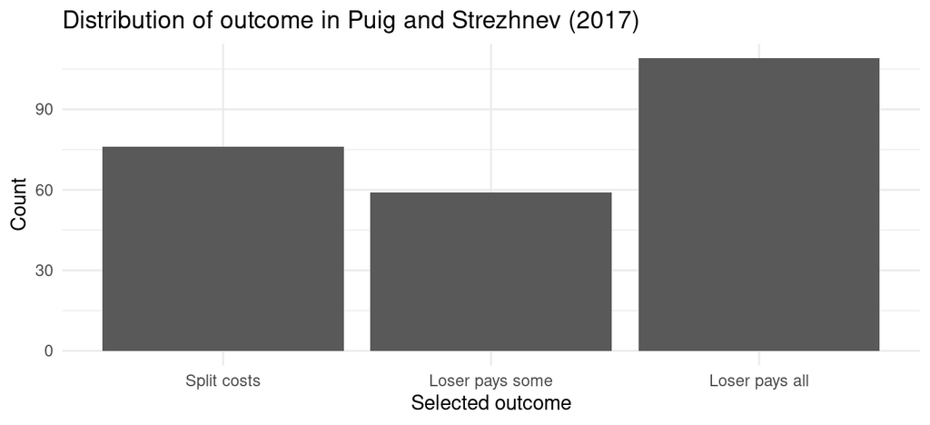

## Example: Appointer Affiliation Bias

- It would seem like an ordinal logit regression would be appropriate – a three-category discrete outcome with a clear ordering
  - Implemented in the `ordinal` package

```r
ordered_logit <- ordinal::clm(isReimbursementFolded_Factor ~ isAppointerSide, data=study1_complete %>%
                       filter(isAppointerSide == "Appointed by Winner"|isAppointerSide == "Appointed by Loser"))
```

```r
summary(ordered_logit)
```

```
formula: isReimbursementFolded_Factor ~ isAppointerSide
data:
study1_complete %>% filter(isAppointerSide == "Appointed by Winner" | isAppointerSide == "Appointed by Loser")

 link  threshold nobs logLik  AIC    niter max.grad cond.H
 logit flexible  123  -128.28 262.57 5(0)  2.98e-13 1.5e+01

Coefficients:
                                   Estimate Std. Error z value Pr(>|z|)
isAppointerSideAppointed by Winner    0.411      0.340    1.21     0.23

Threshold coefficients:
                               Estimate Std. Error z value
Split costs|Loser pays some      -0.672      0.262   -2.56
Loser pays some|Loser pays all    0.302      0.256    1.18
```

## Example: Appointer Affiliation Bias

- The model implies that arbitrators appointed by the winning party shift mostly from **splitting the costs** to making the loser pay for **everything**
  - But is this real or an artifact of the proportional odds assumption? Is there a “constant effect” on the latent variable scale?

```r
ord_me <- marginaleffects::avg_comparisons(ordered_logit)
```

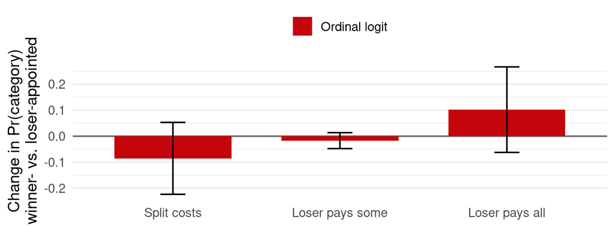

## Example: Appointer Affiliation Bias

- Compare with **multinomial logit** (which in this case is equivalent to OLS for each category since we’re using a fully-saturated regression)

```r
multinom_logit <- nnet::multinom(isReimbursementFolded_Factor ~ isAppointerSide, data=study1_complete %>%
                       filter(isAppointerSide == "Appointed by Winner"|isAppointerSide == "Appointed by Loser"))
```

```r
mnl_me <- marginaleffects::avg_comparisons(multinom_logit)
```

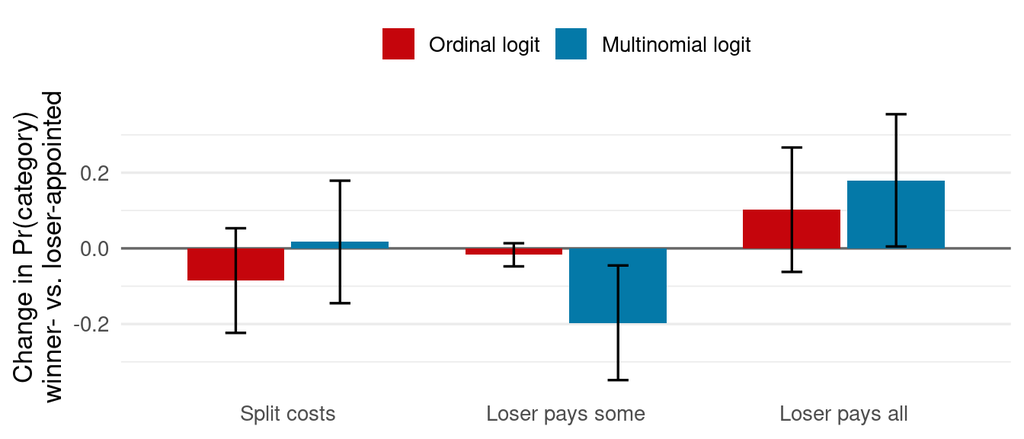

- Running the ordinal logit (as a reviewer asked us to do!) would have given us the **wrong result**
  - Remember, don’t just fixate on the outcome when choosing a modeling strategy - think about what your entire bundle of assumptions implies!

## Conditional logit

- Same latent utility setup as the multinomial logit, but now the covariates are **attribute-specific** but their types are **shared** across alternatives
  - Price of each mode of transportation, the attributes of each profile in a conjoint
- $X_{ik}$ varies across categories, but all categories share a common $\beta$ vector

  $$Y_{ik}^* = X_{ik}^{\prime}\beta + \epsilon_{ik}$$
- With the same i.i.d. Type I extreme value errors, we get the same “softmax” expression for the choice probability.

  $$\Pr(Y_i = k \,|\, X_{i1}, \dotsc, X_{iK}) = \frac{\exp(X_{ik}^{\prime}\beta)}{\sum_{k^\prime=1}^K \exp(X_{ik^\prime}^{\prime}\beta)}$$

## IIA

- We still have the independence of irrelevant alternatives assumption: the relative odds of two choices only depend on those two choices’ attributes.

  $$\frac{\Pr(Y_i = j)}{\Pr(Y_i = k)} = \exp\big((X_{ij} - X_{ik})^{\prime}\beta\big)$$
- Extensions involve imposing additional **hierarchical** structure:
  - **Nested logit** - group similar alternatives and allow correlation within groupings
    - A random effect common to every alternative in the same **group** $g(k)$: $Y_{ik}^* = X_{ik}^{\prime}\beta + \zeta_{i,g(k)} + \epsilon_{ik}$
  - **Mixed logit / random coefficients** – let $\beta$ vary across individuals (Train 2009)
    - **Unit-specific** coefficients drawn from a common distribution: $Y_{ik}^* = X_{ik}^{\prime}\beta_i + \epsilon_{ik}$
  - Increasingly estimated via **Bayesian** methods (for regularization + partial pooling)

## Conjoint experiments

- A **conjoint** experiment shows respondents two (or more) profiles with **randomly assigned** attributes and asks them to pick one.
  - e.g. choosing between two candidates with different backgrounds, partisan affiliation, policy positions, etc…
- Often designed as a forced choice between alternatives described by **alternative-specific** covariates
- In **political science**: analyzed as a factorial experiment
  - Estimand is the **AMCE** (Hainmueller et al. 2014) – the average change in the probability of selection from changing one attribute, marginalizing over the others.
  - Estimated by OLS, no distributional assumptions, “causal” interpretation.
- In literally every other field that does conjoints: analyzed with a **random utility model**
  - Model latent utilities and simulate choice probabilities.

## Example: Workplace democracy

- Mazumder and Yan (2024) ask whether Americans want to work at **democratically governed** firms
  - YouGov Blue, June 2020: 1,002 respondents, four tasks each, pairwise comparison of two hypothetical employers
  - Outcome: at which firm would you **rather work**? (forced choice)
- Each firm profile randomizes **19 attributes**: the one emphasized in the paper is **corporate governance**
  - *Private, non-worker shareholders* (baseline); *Private, one owner*; *Public, shareholders*; *Workers are shareholders*; *Workers on the board*; *Workers elect managers*
  - Plus pay and benefits, hours, location, owners’ race and gender, unionization, political donations, workplace conditions, …
- The paper reports **AMCEs** from OLS. We’ll fit the **conditional logit** to the same choices.

## Example: Workplace democracy

- One row per respondent-task-**profile**: exactly the long format the conditional logit wants
  - We drop the 122 tasks where the respondent picked neither firm, leaving 3,886 tasks from 993 respondents

```r
library(mlogit)
library(sandwich)
cj <- readRDS("data/mazumder_yan_conjoint.rds")
cj %>% select(rid, task, profile, chosen, governance, income, hours) %>% head(4)
```

```
# A tibble: 4 × 7
    rid  task profile chosen governance               income hours
  <int> <dbl>   <int>  <int> <fct>                    <fct>  <fct>
1     1     1       1      1 Workers are shareholders $200k  80
2     1     1       2      0 Private, one owner       $260k  80
3     1     2       1      1 Private, one owner       $90k   40
4     1     2       2      0 Workers on the board     $200k  40
```

- `dfidx()` tells `mlogit` which rows form a choice situation (`task_id`, nested in respondent `rid`) and which alternative each row is (`profile`)

```r
cj <- cj %>% mutate(task_id = paste(rid, task, sep = "_"))
cj_idx <- dfidx(cj, idx = list(c("task_id", "rid"), "profile"))
```

## Example: Workplace democracy

- All 19 attributes are **alternative-specific** with a **generic** coefficient: the first part of the `mlogit` formula
  - `| 0` drops the alternative-specific constant (a preference for whichever profile is listed second)

```r
attributes <- names(cj)[5:23]
cl_formula <- as.formula(paste("chosen ~", paste(attributes, collapse = " + "), "| 0"))
cl_fit <- mlogit(cl_formula, data = cj_idx)
length(coef(cl_fit))
```

```
[1] 73
```

- Respondents complete four tasks each, so cluster by respondent
  - `estfun()` has one row per **task** (one likelihood contribution each), so the cluster vector needs one entry per task

```r
task_rid <- idx(cj_idx)$rid[idx(cj_idx)$profile == 1]
V_cl <- vcovCL(cl_fit, cluster = task_rid)
```

## Example: Workplace democracy

- The coefficients are **part-worths**: each level’s contribution to the systematic component of utility, relative to its attribute’s baseline

```r
gov <- grep("^governance", names(coef(cl_fit)), value = TRUE)
tibble(level = sub("governance", "", gov), part_worth = coef(cl_fit)[gov],
       se = sqrt(diag(V_cl))[gov], odds_ratio = exp(part_worth),
       pr_vs_baseline = plogis(part_worth)) %>% kable(digits = 3)
```

| level | part_worth | se | odds_ratio | pr_vs_baseline |
| --- | --- | --- | --- | --- |
| Private, one owner | 0.061 | 0.088 | 1.06 | 0.515 |
| Public, shareholders | 0.283 | 0.088 | 1.33 | 0.570 |
| Workers are shareholders | 0.420 | 0.091 | 1.52 | 0.604 |
| Workers on the board | 0.359 | 0.090 | 1.43 | 0.589 |
| Workers elect managers | 0.192 | 0.089 | 1.21 | 0.548 |

- Codetermination (**Workers on the board**) beats an otherwise identical firm that is privately owned by non-worker shareholders (the baseline) about **59%** of the time

## Part-worths: the firm

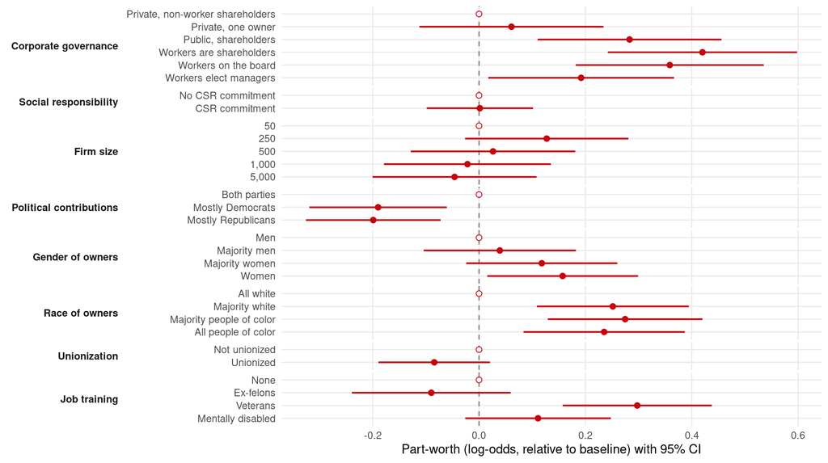

Conditional logit with all 19 attributes; hollow points are baselines. 95% CIs clustered by respondent. Data from Mazumder and Yan (2024).

## Part-worths: the job

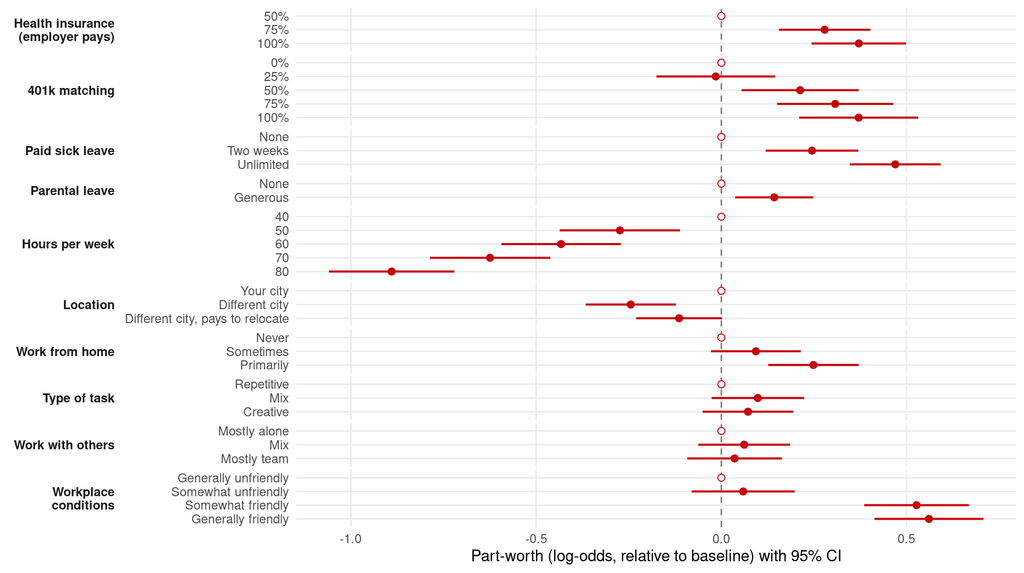

Conditional logit with all 19 attributes; hollow points are baselines. 95% CIs clustered by respondent. Data from Mazumder and Yan (2024).

## Part-worths: salary

- 28 salary levels, so each dummy is noisy. A single **log-salary** term seems to fit well:

```r
cj <- cj %>% mutate(log_salary = log(as.numeric(gsub("[^0-9]", "", income))))
log_formula <- as.formula(paste("chosen ~", paste(c(setdiff(attributes, "income"), "log_salary"), collapse = " + "), "| 0"))
log_fit <- mlogit(log_formula, data = dfidx(cj, idx = list(c("task_id", "rid"), "profile")))
```

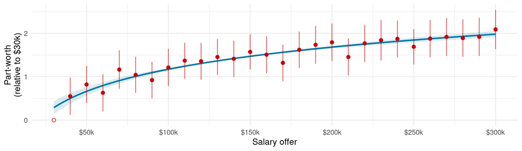

Red: salary dummies with 95% CIs. Blue: log-salary fit with 95% CI, centered on the dummies’ average level. Both clustered by respondent.

## Survival models

## Survival models

- Often we have outcome data that is measured as the “time-to-event”
  - From the medical literature, this is often the number of days before a patient suffers some adverse event (e.g. death).
  - But lots of other applications (e.g. time to treaty ratification)
- Assume we observe $n$ i.i.d. event times $T_1, T_2, \dotsc, T_n$
- Define the “survival function”

  $$S(t) = Pr(T > t) = 1 - F(t)$$
- We’ll also often work with the “hazard” or the “instantaneous” probability of an event happening *given* that it has not yet occurred

  $$h(t) = \underset{\Delta t \to 0}{\lim} \frac{P(t < T_i \le t + \Delta t | T_i > t)}{\Delta t} = \frac{f(t)}{S(t)} = \frac{f(t)}{1-F(t)}$$
- **Intuitively**: Given that I know that an event has not occurred until $t$, what is the probability that it will immediately occur next!

## Survival models

- We’ll also define the cumulative hazard

  $$H(t) = \int_{0}^{t} h(u)du = \int_0^{t} \frac{f(u)}{S(u)} du = -\log(S(t))$$

## Non-parametric approach

- The easiest way to estimate $S(t) = 1 - F(t)$ is to just plug in $\hat{F}(t)$ - our empirical CDF in the sample
  - At any given value $t$, what share of events occur *after* $t$
- **Problem**: This doesn’t address *censoring* of observations – sometimes we stop observing a unit at time $t^*$ rather than observing an actual event.
  - We know that $T_i > t^*$ but not what $T_i$ actually equals
- Let $C = \{C_1, C_2, \dotsc, C_n\}$ denote the **censoring indicator**
  - If $C_i = 1$, then the observation is *censored*, the observed value $t$ only gives us information on $T_i > t$ as opposed to $T_i = t$.
  - Crucially, we assume that censoring is “uninformative”
- One approach to constructing a non-parametric estimator of the survival function *under censoring* is the **Kaplan-Meier** estimator.

## Kaplan-Meier Estimator

- Start by arranging the possible event times from $0 < t_{(1)} < t_{(2)} < t_{(3)} < t_{(4)}, \dotsc, < t_{(n)}$
  - Suppose $t$ is after $t_{(j)}$ and before $t_{(j+1)}$. We can write the survival function in terms of conditional probabilities:

  $$S(t) = Pr(T_i > t | T_i > t_{(j)}) \times Pr(T_i > t_{(j)} | T_i > t_{(j-1)}) \times \dotsc \times Pr(T_i > t_{(2)} | T_i > t_{(1)}) \times Pr(T_i > t_{(1)})$$
- The **Kaplan-Meier** estimator $\hat{S}(t)$ is a “plug-in” estimator for each of these probabilities.

  $$\hat{S}(t) = \prod_{j: t_{(j)} \le t} \bigg(1 - \frac{d_j}{r_j} \bigg)$$
- $d_j$ denotes the number of units that experience an event at time $t_{(j)}$
- $r_j$ is the number of units that are still in the risk set just before $t_{(j)}$
  - Units drop out of the risk set $r$ over time by either experiencing an event or being censored

## Kaplan-Meier Estimator

- **Intuition**: Consider one of the terms in the product. Using the definition of conditional probability:

  $$Pr(T_i > t_{(j)} | T_i > t_{(j-1)}) = 1 - Pr(T_i \le t_{(j)}|T_i > t_{(j-1)}) = 1 - \frac{Pr(T_i \le t_{(j)}, T_i > t_{(j-1)})}{Pr(T_i > t_{(j-1)})}$$
- In the numerator, our “plug-in” estimator is just the share of units that have events occurring at $t_{(j)}$.
- In the denominator we have the share of units that we know for sure are still “active” in the interval after $t_{(j-1)}$
- Hence our overall “plug-in” estimator:

  $$\widehat{Pr}(T_i > t_{(j)} | T_i > t_{(j-1)}) = 1 - \frac{d_j}{r_j}$$
- Taking the product across all of the $j$ where $t_{(j)} \le t$ yields the Kaplan-Meier estimator.

## Illustration: Lung Cancer

- Let’s look at a sample dataset from the `survival` R package on survival times for patients with advanced lung cancer.

```r
library(survival)
data(cancer, package="survival")
as_tibble(lung)
```

```
# A tibble: 228 × 10
    inst  time status   age   sex ph.ecog ph.karno pat.karno meal.cal wt.loss
   <dbl> <dbl>  <dbl> <dbl> <dbl>   <dbl>    <dbl>     <dbl>    <dbl>   <dbl>
 1     3   306      2    74     1       1       90       100     1175      NA
 2     3   455      2    68     1       0       90        90     1225      15
 3     3  1010      1    56     1       0       90        90       NA      15
 4     5   210      2    57     1       1       90        60     1150      11
 5     1   883      2    60     1       0      100        90       NA       0
 6    12  1022      1    74     1       1       50        80      513       0
 7     7   310      2    68     2       2       70        60      384      10
 8    11   361      2    71     2       2       60        80      538       1
 9     1   218      2    53     1       1       70        80      825      16
10     7   166      2    61     1       2       70        70      271      34
# ℹ 218 more rows
```

- We want to estimate $S(t | \text{Sex} = \text{Male})$ and $S(t | \text{Sex} = \text{Female})$

## Illustration: Lung Cancer

- In the `survival` package, we need to define a “survival” outcome in terms of the event time and the censoring indicator

```r
surv_model <- survfit(Surv(time, status) ~ 1, data=lung)
```

## Illustration: Lung Cancer

- Plot the curve for the sample as a whole

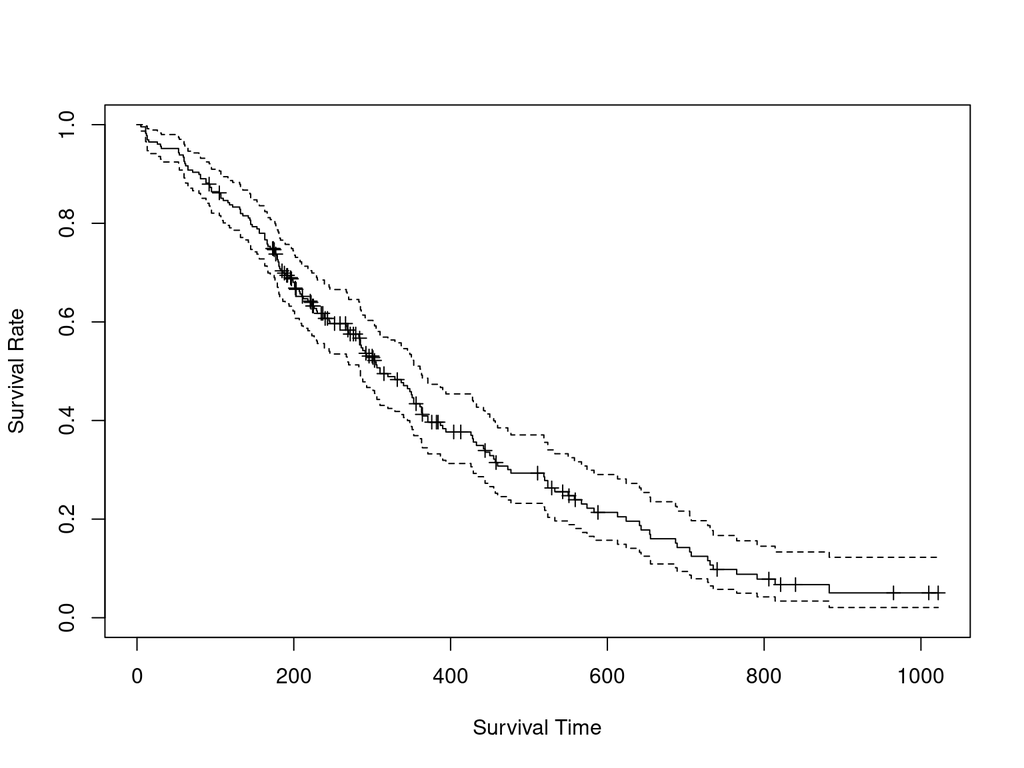

## Illustration: Lung Cancer

- Now let’s do this for gender

```r
surv_model_sex <- survfit(Surv(time, status) ~ I(sex==2), data=lung)
```

## Illustration: Lung Cancer

- Plot separate curves for men and women

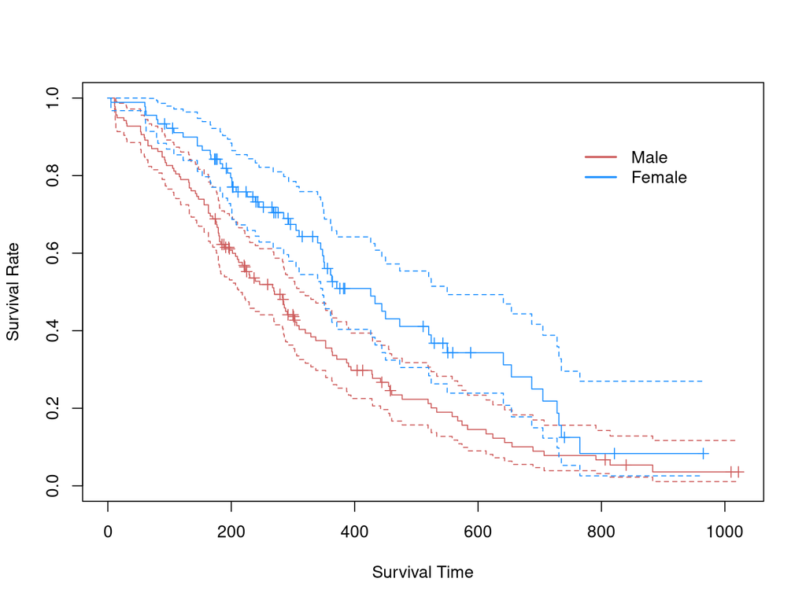

## Parametric inference

- When we want to model the survival function using covariates, we run into a clear constraint using purely non-parametric methods
  - Splitting the sample and constructing separate K-M curves for each unique covariate profile quickly becomes infeasible.
- We may want to assume a **model** for the event time. We can write that density in terms of the *hazard* and the *survival* function

  $$f(t) = h(t)S(t)$$
- Note that by the definition of the cumulative hazard $H(t) = - \log(S(t))$ and $S(t) = \exp(-H(t))$, so

  $$f(t) = h(t)\exp(-H(t))$$

## Parametric inference

- Depending on the assumptions we make about the nature of the hazard, we can obtain different distributions for $f(t)$.
  - In the simplest case, let’s assume that the hazard does not vary over time: $h(t) = \lambda$, with $\lambda > 0$
  - And the cumulative hazard is $H(t) = \int_{0}^{t} \lambda du = \lambda t$
- This yields the **exponential distribution**

  $$f(t) = \lambda \exp(-\lambda t)$$

## Exponential Model

- The mean of $T_i \sim \text{Exponential}(\lambda)$ is $E[T_i] = \frac{1}{\lambda}$. We’ll often reparameterize the mean as $\theta$, yielding a density of

  $$f(t) = \frac{1}{\theta} \exp\bigg(-\frac{1}{\theta} t\bigg)$$
- $\theta$ is strictly greater than $0$, so we’ll use a log-link to incorporate the covariates:

  $$\log(E[T_i | X_i]) = \log(\theta_i) = X_i^{\prime}\beta$$
- Alternatively, we can write

  $$E[T_i | X_i] = \exp(X_i^{\prime}\beta)$$
- Note that the constant hazard assumption is strong
  - The exponential distribution is “memoryless” in that knowing that a unit has survived up until time $t$ tells you nothing about its instantaneous probability of failure.
  - More flexible distributions like the Weibull allow for a time-varying hazard.

## Exponential Model

- We can interpret changes in the linear predictor in terms of changes in the hazard since

$$h(t) = \frac{1}{\theta_i} = \frac{1}{\exp(X_i^{\prime}\beta)}$$

- Increases in the linear predictor reduce the hazard.
- This also lets us write down the survival function

$$S(t) = \exp\bigg(- \frac{1}{\exp(X_i^{\prime}\beta)}t \bigg)$$

## Application

- Let’s compare our parametric fit to the non-parametric Kaplan-Meier estimates

```r
# sex = 2 is a dummy variable for female
exp_model_sex <- survreg(Surv(time, status) ~ I(sex==2), dist="exponential", data=lung)
```

- Get the survival curves for men and women

```r
exp_surv_men <- function(x) pexp(x, rate = 1/exp(coef(exp_model_sex)%*%c(1,0)), lower.tail = F)
exp_surv_women <- function(x) pexp(x, rate = 1/exp(coef(exp_model_sex)%*%c(1,1)), lower.tail=F)
```

## Application

- Overlay the exponential survival curves on the Kaplan-Meier estimates

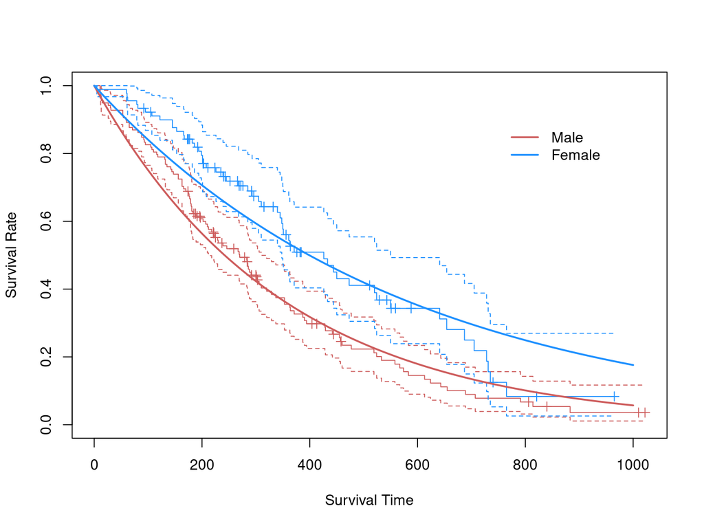

## Application: Weibull

- The fit seems to be off.
  - This is because the hazard appears to be **time-varying**.
  - You can see a kind of “s-curve” which the exponential cannot capture.
- The **Weibull** adds a shape parameter $k$ that lets the hazard change over time

  $$h(t) = \frac{k}{\lambda}\left(\frac{t}{\lambda}\right)^{k-1}\qquad S(t) = \exp\left(-\left(\frac{t}{\lambda}\right)^{k}\right)$$
  - $k = 1$ is the exponential; $k > 1$ is a **rising** hazard, $k < 1$ a falling one

```r
weib_model_sex <- survreg(Surv(time, status) ~ I(sex==2), dist="weibull", data=lung)
```

## Application: Weibull

- Get the Weibull survival curves ($\lambda_i = \exp(X_i^{\prime}\beta)$) and overlay them on Kaplan-Meier

```r
weib_surv_men <- function(x) pweibull(x, shape = 1/weib_model_sex$scale,
                                       scale = exp(coef(weib_model_sex)%*%c(1,0)), lower.tail = F)
weib_surv_women <- function(x) pweibull(x, shape = 1/weib_model_sex$scale,
                                         scale = exp(coef(weib_model_sex)%*%c(1,1)), lower.tail = F)
```

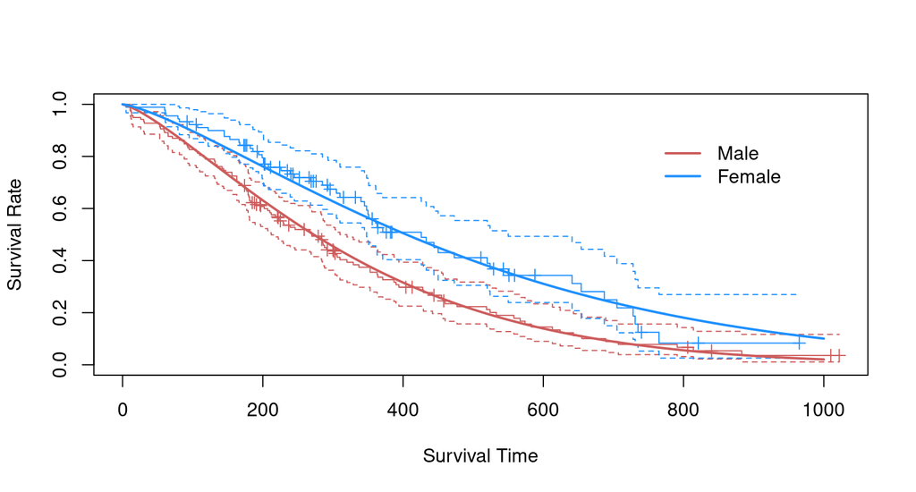

## Cox Proportional Hazards

- The **Cox proportional hazards model** assumes that covariates enter the hazard log-linearly, but the baseline hazard is unspecified

$$h_i(t) = h_0(t)\exp(X_i^{\prime}\beta)$$

- $h_0(t)$ is the unknown baseline hazard function.
- Note that while the baseline hazard is not explicitly identified, the ratio of the hazards of two observations $i$ and $j$ at time $t$ **does not depend on the baseline**

  $$\frac{h_i(t)}{h_j(t)} = \frac{\exp(X_i^{\prime}\beta)}{\exp(X_j^{\prime}\beta)}$$
- The model is **semi-parametric** in that some components are left entirely unspecified…
  - …but others are not – we assume that the covariates act **proportionally** on the hazard irrespective of time.

## Cox Proportional Hazards

- The model is estimated by maximizing a **partial likelihood**
  - We observe event time $Y_i$ - assume no ties
- The individual partial likelihood is

  $$L_i(\beta) = \frac{\exp(X_i^{\prime}\beta)}{\sum_{k; Y_k \ge Y_i} \exp(X_k^{\prime}\beta)}$$
- **Intuitively**: The denominator contains the hazards of all observations in the **risk set** at the event time $Y_i$
- Then the full likelihood is just the product over all the individual partial likelihoods

  $$L(\beta) = \prod_{i: C_i = 0} \frac{\exp(X_i^{\prime}\beta)}{\sum_{k; Y_k \ge Y_i} \exp(X_k^{\prime}\beta)}$$

## Cox and conditional logit

- The individual partial likelihood should look familiar - it has exactly the form of the **conditional logit**

  $$L_i(\beta) = \frac{\exp(X_i^{\prime}\beta)}{\sum_{k; Y_k \ge Y_i} \exp(X_k^{\prime}\beta)}$$
- At each event time we are asking: given that **one** unit in the risk set failed, which one was it?
  - The “choice set” is the risk set $\{k: Y_k \ge Y_i\}$, and the “chosen alternative” is the unit that failed.

## Application

- What does the Cox fit look like

```r
# sex = 2 is a dummy variable for female
cox_model_sex <- coxph(Surv(time, status) ~ I(sex==2), data=lung)
print(cox_model_sex)
```

```
Call:
coxph(formula = Surv(time, status) ~ I(sex == 2), data = lung)

                coef exp(coef) se(coef)  z     p
I(sex == 2)TRUE -0.5       0.6      0.2 -3 0.001

Likelihood ratio test=11  on 1 df, p=0.001
n= 228, number of events= 165
```

- Note that we **don’t get** an estimate of the hazard because the baseline is left unspecified
  - If we want to plot survival curves, we’ll need some estimate of $h_0$ using another method (like Kaplan-Meier)

## Application

- Estimate the baseline cumulative hazard non-parametrically (the Breslow estimator) and get the Cox-predicted survival curves for men and women

```r
cox_surv_sex <- survfit(cox_model_sex, newdata = data.frame(sex = c(1, 2)))
```

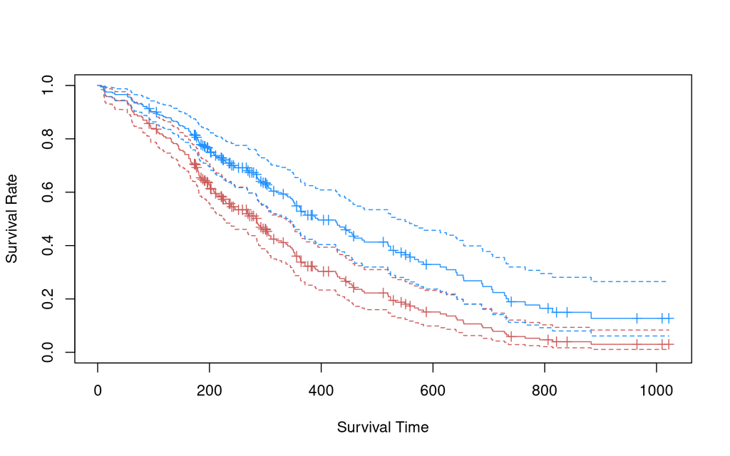

## Next week

- **Introduction to Bayesian inference**
  - What happens if we assume parameters are not fixed but carry uncertainty?
  - The **posterior distribution** $p(\theta | \mathbf{Y})$ as a target of inference
  - The **prior distribution** and how it shapes the posterior.
- **Midterm Exam**

## References

Hainmueller, Jens, Daniel J. Hopkins, and Teppei Yamamoto. 2014. “Causal Inference in Conjoint Analysis: Understanding Multidimensional Choices via Stated Preference Experiments.” *Political Analysis* 22 (1): 1–30. https://doi.org/10.1093/pan/mpt024.

Mazumder, Soumyajit, and Alan N. Yan. 2024. “What Do Americans Want from (Private) Government? Experimental Evidence Demonstrates That Americans Want Workplace Democracy.” *American Political Science Review* 118 (2): 1020–36. https://doi.org/10.1017/S0003055423000667.

Puig, Sergio, and Anton Strezhnev. 2017. “Affiliation Bias in Arbitration: An Experimental Approach.” *Journal of Legal Studies* 46 (2): 371–89. https://doi.org/10.1086/694254.

Train, Kenneth E. 2009. *Discrete Choice Methods with Simulation*. 2nd ed. Cambridge University Press. https://doi.org/10.1017/CBO9780511805271.